# Estatística Multivariada - Atividade Prática 2 - Análise Fatorial

Elton Dantas de Oliveira Mesquita

## Pacotes

```r
#install.packages("dplyr")
library(dplyr)

#install.packages("psych")
library(psych)

#install.packages("factoextra")
library(factoextra)

#install.packages("corrplot")
library(corrplot)
```

## Dados

Nessa atividade, realizaremos uma análise fatorial exploratória no conjunto de dados a seguir, a fim de reduzirmos a sua dimensionalidade. Os dados consistem nas marcas obtidas pelas atletas de diversos países por ocasião dos Jogos Olímpicos de Los Angeles (1984) e suas variáveis representam os tempos registrados por elas nas seguintes competições:

- *100m (s)*: Corrida de 100m (em segundos);
- *200m (s)*: Corrida de 200m (em segundos);
- *400m (s)*: Corrida de 400m (em segundos);
- *800m (min)*: Corrida de 800m (em minutos);
- *1500m (min)*: Corrida de 1500m (em minutos);
- *3000m (min)*: Corrida de 3000m (em minutos);
- *Maratona (min)*: Maratona (em minutos).

```r
# Importando os dados
dados = read.table("T1-9.DAT")

# Nomeando as linhas com os nomes dos países
row.names(dados) = dados[,8]

# Removendo a coluna de países
dados = dados[,-8]

# Nomeando as variáveis
variaveis = c("100m (s)","200m (s)","400m (s)","800m (min)",
              "1500m (min)","3000m (min)", "Maratona (min)")
colnames(dados) = variaveis

# Breve visualização dos dados
head(dados,5)
```

```
##          100m (s) 200m (s) 400m (s) 800m (min) 1500m (min) 3000m (min)
## argentin    11.61    22.94    54.50       2.15        4.43        9.79
## australi    11.20    22.35    51.08       1.98        4.13        9.08
## austria     11.43    23.09    50.62       1.99        4.22        9.34
## belgium     11.41    23.04    52.00       2.00        4.14        8.88
## bermuda     11.46    23.05    53.30       2.16        4.58        9.81
##          Maratona (min)
## argentin         178.52
## australi         152.37
## austria          159.37
## belgium          157.85
## bermuda          169.98
```

```r
# Algumas estatísticas descritivas
describe(dados)
```

```
##                vars  n   mean    sd median trimmed   mad    min    max  range
## 100m (s)          1 55  11.62  0.45  11.60   11.60  0.52  10.79  12.90   2.11
## 200m (s)          2 55  23.64  1.11  23.54   23.59  1.10  21.71  27.10   5.39
## 400m (s)          3 55  53.41  2.68  53.30   53.34  2.64  47.99  60.40  12.41
## 800m (min)        4 55   2.08  0.11   2.05    2.07  0.10   1.89   2.33   0.44
## 1500m (min)       5 55   4.33  0.33   4.25    4.29  0.27   3.87   5.81   1.94
## 3000m (min)       6 55   9.45  0.82   9.34    9.35  0.74   8.45  13.04   4.59
## Maratona (min)    7 55 173.25 30.43 164.65  167.75 19.60 142.72 306.00 163.28
##                skew kurtosis   se
## 100m (s)       0.44     0.03 0.06
## 200m (s)       0.50     0.22 0.15
## 400m (s)       0.19    -0.27 0.36
## 800m (min)     0.44    -0.65 0.01
## 1500m (min)    1.76     5.06 0.04
## 3000m (min)    1.70     4.56 0.11
## Maratona (min) 2.18     5.64 4.10
```

Como as variáveis são medidas em unidades diferentes, faremos a análise utilizando a matriz de correlações amostral.

## Correlações

Visualizando as correlações entre as variáveis:

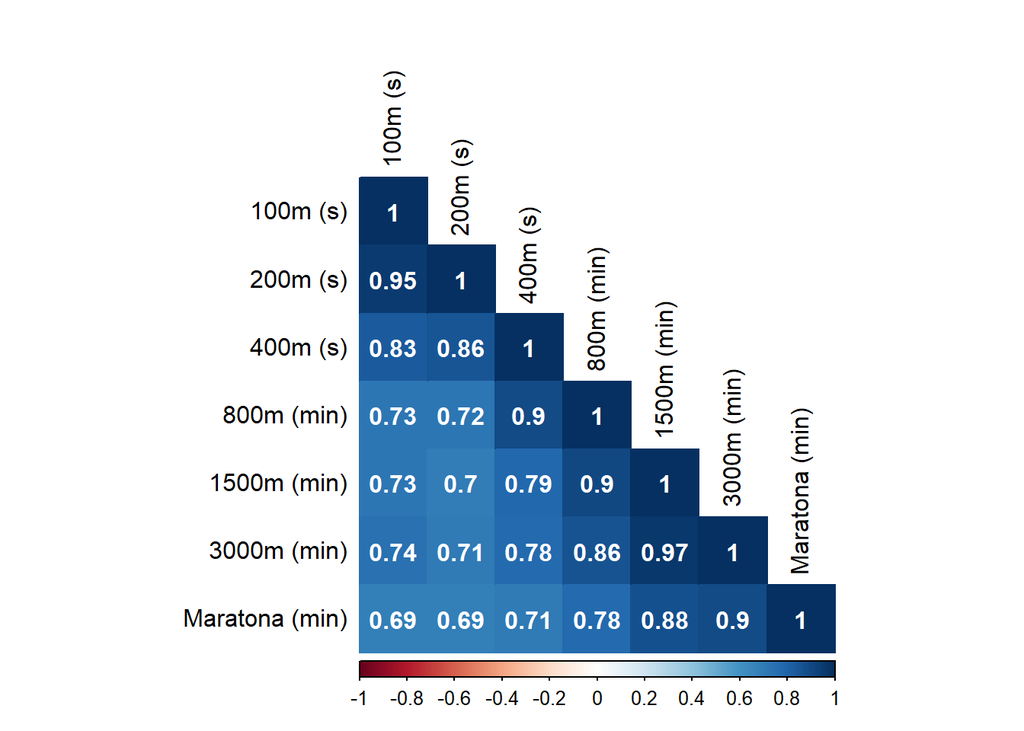

```r
corrplot(cor(dados),
         method = "color",
         type = "lower",
         addCoef.col = "white",
         tl.col = "black")
```

Verificamos pela figura acima que as correlações são todas positivas e variam de 0,69 a 0,97.

## Medidas de adequação amostral

Para testar a conveniência do modelo fatorial, aplicaremos dois testes a seguir:

### Teste de esfericidade de Bartlett

$H_0:$ a matriz de correlação da população é uma matriz identidade, ou seja, as variáveis são não-correlacionadas na população.

Um valor elevado da estatística de teste favorece a rejeição da hipótese nula.

```r
cortest.bartlett(dados)
```

```
## $chisq
## [1] 605.3355
##
## $p.value
## [1] 1.207034e-114
##
## $df
## [1] 21
```

O p-valor obtido com o teste de Bartlett foi extremamente baixo. Ao nível de significância de 5%, rejeitamos a hipótese de que as variáveis não são correlacionadas na população.

### Medida de Adequação Amostral KMO

A medida de adequação amostral de Kaiser-Meyer-Olkin compara as magnitudes dos coeficientes de correlação observados com as magnitudes dos coeficientes de correlação parcial. Pequenos valores de KMO indicam que as correlações entre os pares de variáveis não podem ser explicadas por outras variáveis, indicando que a análise fatorial não é adequada.

```r
KMO(dados)
```

```
## Kaiser-Meyer-Olkin factor adequacy
## Call: KMO(r = dados)
## Overall MSA =  0.84
## MSA for each item =
##       100m (s)       200m (s)       400m (s)     800m (min)    1500m (min)
##           0.83           0.80           0.84           0.83           0.82
##    3000m (min) Maratona (min)
##           0.84           0.93
```

Todas as variáveis obtiveram adequação meritória com valores a partir de 0,8. A estatística KMO de 0,84 obtida, juntamente ao teste anterior, também concorda que a análise fatorial é apropriada para analisarmos a matriz de correlação.

## Análise Fatorial

A seguir, vamos obter os fatores através do método das componentes principais com a matriz de correlações amostral.

```r
PCA = princomp(dados, cor = TRUE)
summary(PCA)
```

```
## Importance of components:
##                           Comp.1     Comp.2     Comp.3     Comp.4      Comp.5
## Standard deviation     2.4094991 0.80848347 0.54761522 0.35422802 0.231984732
## Proportion of Variance 0.8293837 0.09337793 0.04284035 0.01792536 0.007688131
## Cumulative Proportion  0.8293837 0.92276161 0.96560196 0.98352731 0.991215445
##                             Comp.6      Comp.7
## Standard deviation     0.197608919 0.149808546
## Proportion of Variance 0.005578469 0.003206086
## Cumulative Proportion  0.996793914 1.000000000
```

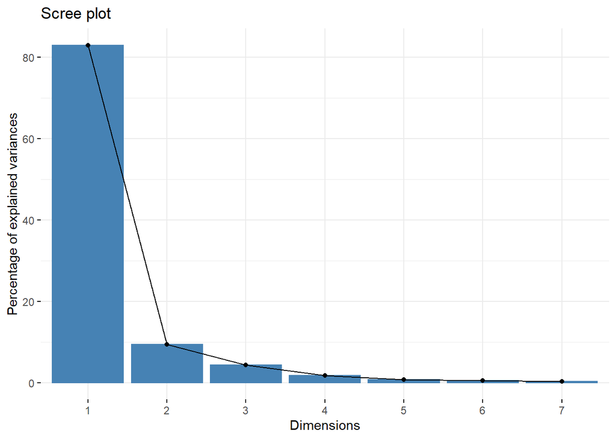

```r
fviz_screeplot(PCA)
```

Autovalores:

```r
PCA$sdev^2
```

```
##     Comp.1     Comp.2     Comp.3     Comp.4     Comp.5     Comp.6     Comp.7
## 5.80568576 0.65364552 0.29988243 0.12547749 0.05381692 0.03904928 0.02244260
```

A primeira componente principal corresponde a 83% da variância total dos dados padronizados. Se tomarmos as duas primeiras componentes, essa proporção é de 92%. Também pelo gráfico screeplot, vemos que a porcentagem de variâncias explicadas fica cada vez menor e menos relevante a partir da terceira componente. Então, por esses critérios, estimaremos o número de fatores m = 2 para a nossa análise.

### Matriz de fatores - componentes principais - m = 2

```r
princ = principal(dados, nfactors = 2, rotate = "none", scores = TRUE)
princ
```

```
## Principal Components Analysis
## Call: principal(r = dados, nfactors = 2, rotate = "none", scores = TRUE)
## Standardized loadings (pattern matrix) based upon correlation matrix
##                 PC1   PC2   h2    u2 com
## 100m (s)       0.89  0.40 0.94 0.055 1.4
## 200m (s)       0.88  0.43 0.96 0.037 1.5
## 400m (s)       0.92  0.20 0.89 0.115 1.1
## 800m (min)     0.93 -0.13 0.87 0.126 1.0
## 1500m (min)    0.94 -0.29 0.96 0.036 1.2
## 3000m (min)    0.94 -0.28 0.96 0.043 1.2
## Maratona (min) 0.88 -0.30 0.87 0.129 1.2
##
##                        PC1  PC2
## SS loadings           5.81 0.65
## Proportion Var        0.83 0.09
## Cumulative Var        0.83 0.92
## Proportion Explained  0.90 0.10
## Cumulative Proportion 0.90 1.00
##
## Mean item complexity =  1.2
## Test of the hypothesis that 2 components are sufficient.
##
## The root mean square of the residuals (RMSR) is  0.04
##  with the empirical chi square  3.16  with prob <  0.92
##
## Fit based upon off diagonal values = 1
```

A matriz de fatores acima, resultante da análise de componentes principais, é composta pelos coeficientes (cargas fatoriais) que expressam as variáveis padronizadas em termos dos fatores. Valores altos das cargas fatoriais representam boa relação entre a variável e o fator. Essa matriz não rotacionada apresenta dificuldades para ser interpretada, porque o fator 1 está altamente correlacionado com todas as variáveis.

### Matriz de fatores - rotação varimax - m = 2

Com o objetivo de possibilitar uma melhor interpretação dos fatores, é comum fazermos uma transformação/rotação dos fatores. Na rotação ortogonal, os eixos são mantidos em ângulo reto e o método mais utilizado é o varimax. Esse método de rotação minimiza o número de variáveis com altas cargas sobre um fator, a fim de permitir a interpretação dos fatores. Vejamos a baixo:

```r
princ2 = principal(dados, nfactors = 2, rotate = "varimax", scores = TRUE)
princ2
```

```
## Principal Components Analysis
## Call: principal(r = dados, nfactors = 2, rotate = "varimax", scores = TRUE)
## Standardized loadings (pattern matrix) based upon correlation matrix
##                 RC1  RC2   h2    u2 com
## 100m (s)       0.41 0.88 0.94 0.055 1.4
## 200m (s)       0.38 0.91 0.96 0.037 1.3
## 400m (s)       0.56 0.76 0.89 0.115 1.8
## 800m (min)     0.78 0.52 0.87 0.126 1.7
## 1500m (min)    0.90 0.40 0.96 0.036 1.4
## 3000m (min)    0.89 0.41 0.96 0.043 1.4
## Maratona (min) 0.86 0.36 0.87 0.129 1.3
##
##                        RC1  RC2
## SS loadings           3.56 2.90
## Proportion Var        0.51 0.41
## Cumulative Var        0.51 0.92
## Proportion Explained  0.55 0.45
## Cumulative Proportion 0.55 1.00
##
## Mean item complexity =  1.5
## Test of the hypothesis that 2 components are sufficient.
##
## The root mean square of the residuals (RMSR) is  0.04
##  with the empirical chi square  3.16  with prob <  0.92
##
## Fit based upon off diagonal values = 1
```

Com a matriz rotacionada pelo método varimax, podemos ver que o fator 1 apresenta altas cargas para as variáveis mensuradas em minutos, isto é, as variáveis referentes às provas de 800m, 1500m, 3000m e maratona. Já o fator 2 tem maiores cargas nas demais variáveis, referentes às provas mensuradas em segundos. Então, podemos interpretar esses fatores como:

Fator 1: desempenho em provas de longa distância.

Fator 2: desempenho em provas de curta distância.

### Antes e depois da rotação

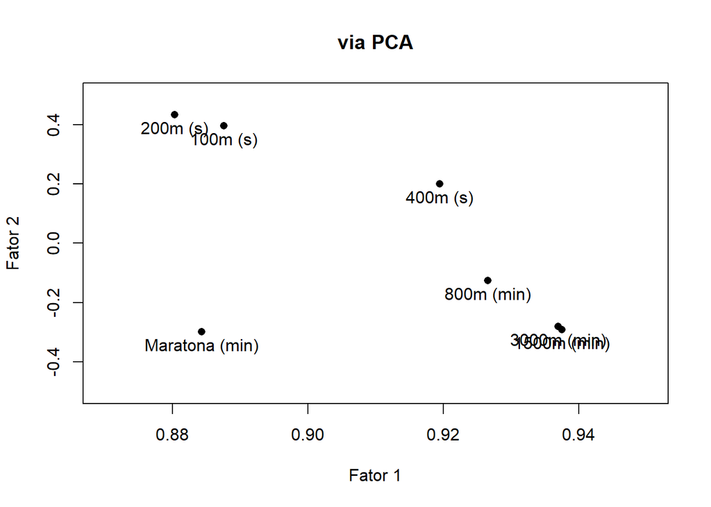

```r
plot(princ$loadings, xlim = c(0.87,0.95), ylim = c(-0.5,0.5), pch = 16,
     xlab = "Fator 1", ylab = "Fator 2", main = "via PCA")
text(princ$loadings, rownames(princ$loadings), adj = c(0.5,1.5))
```

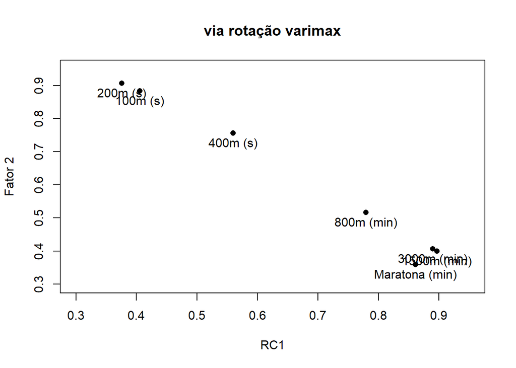

```r
plot(princ2$loadings, xlim = c(0.3,0.95), ylim = c(0.3,0.95), pch = 16,
     ylab = "Fator 2", main = "via rotação varimax")
text(princ2$loadings, rownames(princ2$loadings), adj = c(0.5,1.5))
```

Comparando os dois gráficos, percebemos que após a rotação pelo método varimax há uma separação mais nítida das variáveis em relação aos fatores. Com a rotação, as variáveis 100m, 200m e 400m têm cargas mais altas no fator 2, enquanto que as variáveis 800m, 1500m, 3000m e Maratona têm cargas mais altas no fator 1.

Por fim, com os fatores interpretados, faremos um ranking dos escores a partir deles.

```r
scores = as.data.frame(princ2$scores)
scores
```

```
##                  RC1         RC2
## argentin  0.71500331 -0.48283260
## australi -0.21824214 -1.06845994
## austria  -0.20617932 -0.63357526
## belgium  -0.54519591 -0.32886267
## bermuda   0.91767905 -0.80145022
## brazil    0.70683713 -0.87972366
## burma     0.04632274  1.00542397
## canada   -0.24615649 -1.36039006
## chile    -0.78538174  1.23936529
## china    -0.59966957  1.08658598
## columbia -0.08188407  0.18234853
## cookis    0.75358226  2.96481554
## costa     0.56729882  1.00152145
## czech    -0.12613962 -1.77749057
## denmark  -0.78893134  0.19643257
## domrep    1.21867100  0.05576723
## finland  -0.13362523 -1.22040041
## france   -0.22802420 -0.93062413
## gdr      -0.11234256 -2.07770529
## frg      -0.55587340 -1.20739188
## gbni     -0.39616482 -1.29960880
## greece    0.06326334  0.44018350
## guatemal  1.75652843  0.02928115
## hungary  -0.50920488 -0.34924406
## india     0.10950492  0.51351074
## indonesi  0.96751125  0.22671855
## ireland  -0.76713258  0.17098535
## israel   -0.17177439  0.10574466
## italy    -0.95454562 -0.25858606
## japan    -0.55535934  0.59540850
## kenya    -0.52656021  0.32878229
## korea    -0.27967481  1.09484987
## dprkorea -1.25754392  1.72344837
## luxembou -0.55859438  1.45530520
## malaysia  0.73105122  0.63964251
## mauritiu  2.28356115  0.06211348
## mexico   -0.48406028  0.51151044
## netherla -0.52126948 -0.53506347
## nz       -0.77973893 -0.06246668
## norway   -1.20034995  0.43447080
## png       1.51927559  0.77363985
## philippi  1.22640356 -0.36526736
## poland   -0.26036644 -1.38444291
## portugal -1.09208506  1.10301715
## rumania  -1.13741696  0.01876642
## singapor -0.16229239  1.42432471
## spain    -0.86608875  0.76291316
## sweden   -0.36215960 -0.73729089
## switzerl -0.83958150  0.10926229
## taipei    0.85144581 -1.28461082
## thailand  0.72333696  0.40473798
## turkey    0.01664253  0.99278577
## usa      -0.48143226 -1.55015501
## ussr     -0.88067544 -1.17640931
## wsamoa    4.49779854  0.11838877
```

### Ranking do fator 1: Provas de longa distância

```r
scores %>% arrange(desc(RC1))
```

```
##                  RC1         RC2
## wsamoa    4.49779854  0.11838877
## mauritiu  2.28356115  0.06211348
## guatemal  1.75652843  0.02928115
## png       1.51927559  0.77363985
## philippi  1.22640356 -0.36526736
## domrep    1.21867100  0.05576723
## indonesi  0.96751125  0.22671855
## bermuda   0.91767905 -0.80145022
## taipei    0.85144581 -1.28461082
## cookis    0.75358226  2.96481554
## malaysia  0.73105122  0.63964251
## thailand  0.72333696  0.40473798
## argentin  0.71500331 -0.48283260
## brazil    0.70683713 -0.87972366
## costa     0.56729882  1.00152145
## india     0.10950492  0.51351074
## greece    0.06326334  0.44018350
## burma     0.04632274  1.00542397
## turkey    0.01664253  0.99278577
## columbia -0.08188407  0.18234853
## gdr      -0.11234256 -2.07770529
## czech    -0.12613962 -1.77749057
## finland  -0.13362523 -1.22040041
## singapor -0.16229239  1.42432471
## israel   -0.17177439  0.10574466
## austria  -0.20617932 -0.63357526
## australi -0.21824214 -1.06845994
## france   -0.22802420 -0.93062413
## canada   -0.24615649 -1.36039006
## poland   -0.26036644 -1.38444291
## korea    -0.27967481  1.09484987
## sweden   -0.36215960 -0.73729089
## gbni     -0.39616482 -1.29960880
## usa      -0.48143226 -1.55015501
## mexico   -0.48406028  0.51151044
## hungary  -0.50920488 -0.34924406
## netherla -0.52126948 -0.53506347
## kenya    -0.52656021  0.32878229
## belgium  -0.54519591 -0.32886267
## japan    -0.55535934  0.59540850
## frg      -0.55587340 -1.20739188
## luxembou -0.55859438  1.45530520
## china    -0.59966957  1.08658598
## ireland  -0.76713258  0.17098535
## nz       -0.77973893 -0.06246668
## chile    -0.78538174  1.23936529
## denmark  -0.78893134  0.19643257
## switzerl -0.83958150  0.10926229
## spain    -0.86608875  0.76291316
## ussr     -0.88067544 -1.17640931
## italy    -0.95454562 -0.25858606
## portugal -1.09208506  1.10301715
## rumania  -1.13741696  0.01876642
## norway   -1.20034995  0.43447080
## dprkorea -1.25754392  1.72344837
```

### Ranking do fator 2: Provas de curta distância

```r
scores %>% arrange(desc(RC2))
```

```
##                  RC1         RC2
## cookis    0.75358226  2.96481554
## dprkorea -1.25754392  1.72344837
## luxembou -0.55859438  1.45530520
## singapor -0.16229239  1.42432471
## chile    -0.78538174  1.23936529
## portugal -1.09208506  1.10301715
## korea    -0.27967481  1.09484987
## china    -0.59966957  1.08658598
## burma     0.04632274  1.00542397
## costa     0.56729882  1.00152145
## turkey    0.01664253  0.99278577
## png       1.51927559  0.77363985
## spain    -0.86608875  0.76291316
## malaysia  0.73105122  0.63964251
## japan    -0.55535934  0.59540850
## india     0.10950492  0.51351074
## mexico   -0.48406028  0.51151044
## greece    0.06326334  0.44018350
## norway   -1.20034995  0.43447080
## thailand  0.72333696  0.40473798
## kenya    -0.52656021  0.32878229
## indonesi  0.96751125  0.22671855
## denmark  -0.78893134  0.19643257
## columbia -0.08188407  0.18234853
## ireland  -0.76713258  0.17098535
## wsamoa    4.49779854  0.11838877
## switzerl -0.83958150  0.10926229
## israel   -0.17177439  0.10574466
## mauritiu  2.28356115  0.06211348
## domrep    1.21867100  0.05576723
## guatemal  1.75652843  0.02928115
## rumania  -1.13741696  0.01876642
## nz       -0.77973893 -0.06246668
## italy    -0.95454562 -0.25858606
## belgium  -0.54519591 -0.32886267
## hungary  -0.50920488 -0.34924406
## philippi  1.22640356 -0.36526736
## argentin  0.71500331 -0.48283260
## netherla -0.52126948 -0.53506347
## austria  -0.20617932 -0.63357526
## sweden   -0.36215960 -0.73729089
## bermuda   0.91767905 -0.80145022
## brazil    0.70683713 -0.87972366
## france   -0.22802420 -0.93062413
## australi -0.21824214 -1.06845994
## ussr     -0.88067544 -1.17640931
## frg      -0.55587340 -1.20739188
## finland  -0.13362523 -1.22040041
## taipei    0.85144581 -1.28461082
## gbni     -0.39616482 -1.29960880
## canada   -0.24615649 -1.36039006
## poland   -0.26036644 -1.38444291
## usa      -0.48143226 -1.55015501
## czech    -0.12613962 -1.77749057
## gdr      -0.11234256 -2.07770529
```